# Assignment 0

DATA 311

Author

Noah Semashkewich - 53882783

# Introduction

Hello, my name is **Noah Semashkewich**. I am a **third** year student at **the University of British Columbia**. I am currently taking a Bachelor of Science with a major in *computer science*, and a minor in *data science*. I love to learn about computers and learn how to build new project all the time.

My favorite hobbies include **playing** and **creating** video games, listening to a wide variety of music and **collecting records**, as well as **hiking and exploring outdoors**.

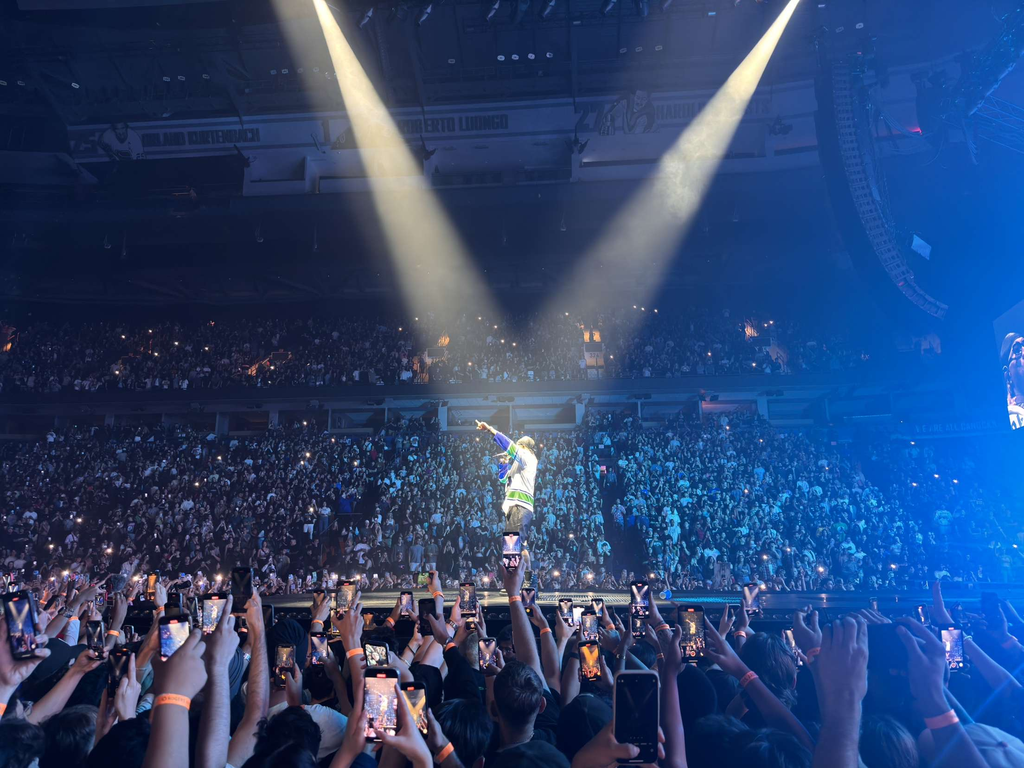

This is a picture from a concert in Vancouver I attended for my birthday with my girlfriend. It was very exciting. The artist’s name is Future.

## Data Wrangling

```r
setwd("~/DATA311/assignment0")
sales = read.csv("sales_data.csv")

#6. Displaying first few rows of the data
head(sales)
```

|  | Date | Order.ID | Product.Name | Category | Price | Quantity.Sold | Total.Sales | Customer.ID | Customer.Age | Customer.Gender | Payment.Method | Store.Location |
| --- | --- | --- | --- | --- | --- | --- | --- | --- | --- | --- | --- | --- |
| 1 | 2023-01-01 | ORD1001 | Smartphone | Mobile | 299.99 | 1 | 299.99 | CUST500 | 34 | Female | Credit Card | New York |
| 2 | 2023-01-02 | ORD1002 | Laptop | Computers | 899.99 | 2 | 1799.98 | CUST501 | 29 | Male | Cash | Los Angeles |
| 3 | 2023-01-03 | ORD1003 | Headphones | Accessories | 49.99 | 3 | 149.97 | CUST502 | 42 | Non-binary | PayPal | Chicago |
| 4 | 2023-01-04 | ORD1004 | Tablet | Mobile | 199.99 | 1 | 199.99 | CUST503 | 38 | Female | Credit Card | New York |
| 5 | 2023-01-05 | ORD1005 | Smartphone | Mobile | 299.99 | 2 | 599.98 | CUST504 | 25 | Male | Credit Card | Chicago |
| 6 | 2023-01-06 | ORD1006 | Smartwatch | Accessories | 149.99 | 1 | 149.99 | CUST505 | 31 | Female | Cash | Los Angeles |

```r
# Displaying data structure
str(sales)
```

```
'data.frame':   30 obs. of  12 variables:
 $ Date           : chr  "2023-01-01" "2023-01-02" "2023-01-03" "2023-01-04" ...
 $ Order.ID       : chr  "ORD1001" "ORD1002" "ORD1003" "ORD1004" ...
 $ Product.Name   : chr  "Smartphone" "Laptop" "Headphones" "Tablet" ...
 $ Category       : chr  "Mobile" "Computers" "Accessories" "Mobile" ...
 $ Price          : num  300 900 50 200 300 ...
 $ Quantity.Sold  : int  1 2 3 1 2 1 1 2 1 2 ...
 $ Total.Sales    : num  300 1800 150 200 600 ...
 $ Customer.ID    : chr  "CUST500" "CUST501" "CUST502" "CUST503" ...
 $ Customer.Age   : int  34 29 42 38 25 31 27 40 35 33 ...
 $ Customer.Gender: chr  "Female" "Male" "Non-binary" "Female" ...
 $ Payment.Method : chr  "Credit Card" "Cash" "PayPal" "Credit Card" ...
 $ Store.Location : chr  "New York" "Los Angeles" "Chicago" "New York" ...
```

```r
#7. Removing duplicate rows from the dataset
unique(sales)
```

|  | Date | Order.ID | Product.Name | Category | Price | Quantity.Sold | Total.Sales | Customer.ID | Customer.Age | Customer.Gender | Payment.Method | Store.Location |
| --- | --- | --- | --- | --- | --- | --- | --- | --- | --- | --- | --- | --- |
| 1 | 2023-01-01 | ORD1001 | Smartphone | Mobile | 299.99 | 1 | 299.99 | CUST500 | 34 | Female | Credit Card | New York |
| 2 | 2023-01-02 | ORD1002 | Laptop | Computers | 899.99 | 2 | 1799.98 | CUST501 | 29 | Male | Cash | Los Angeles |
| 3 | 2023-01-03 | ORD1003 | Headphones | Accessories | 49.99 | 3 | 149.97 | CUST502 | 42 | Non-binary | PayPal | Chicago |
| 4 | 2023-01-04 | ORD1004 | Tablet | Mobile | 199.99 | 1 | 199.99 | CUST503 | 38 | Female | Credit Card | New York |
| 5 | 2023-01-05 | ORD1005 | Smartphone | Mobile | 299.99 | 2 | 599.98 | CUST504 | 25 | Male | Credit Card | Chicago |
| 6 | 2023-01-06 | ORD1006 | Smartwatch | Accessories | 149.99 | 1 | 149.99 | CUST505 | 31 | Female | Cash | Los Angeles |
| 7 | 2023-01-07 | ORD1007 | Laptop | Computers | 799.99 | 1 | 799.99 | CUST506 | 27 | Male | PayPal | New York |
| 8 | 2023-01-08 | ORD1008 | Tablet | Mobile | 249.99 | 2 | 499.98 | CUST507 | 40 | Non-binary | Credit Card | Chicago |
| 9 | 2023-01-09 | ORD1009 | Smartphone | Mobile | 349.99 | 1 | 349.99 | CUST508 | 35 | Female | Credit Card | Los Angeles |
| 10 | 2023-01-10 | ORD1010 | Headphones | Accessories | 59.99 | 2 | 119.98 | CUST509 | 33 | Male | Cash | New York |

[output cut: 20 more lines]

```r
#8. Checking for missing values (none)
which(is.na(sales))
```

```
integer(0)
```

```r
#9. Filtering dataset to display only sales made in New York
sales_ny = sales[sales$Store.Location == "New York", ]
sales_ny
```

|  | Date | Order.ID | Product.Name | Category | Price | Quantity.Sold | Total.Sales | Customer.ID | Customer.Age | Customer.Gender | Payment.Method | Store.Location |
| --- | --- | --- | --- | --- | --- | --- | --- | --- | --- | --- | --- | --- |
| 1 | 2023-01-01 | ORD1001 | Smartphone | Mobile | 299.99 | 1 | 299.99 | CUST500 | 34 | Female | Credit Card | New York |
| 4 | 2023-01-04 | ORD1004 | Tablet | Mobile | 199.99 | 1 | 199.99 | CUST503 | 38 | Female | Credit Card | New York |
| 7 | 2023-01-07 | ORD1007 | Laptop | Computers | 799.99 | 1 | 799.99 | CUST506 | 27 | Male | PayPal | New York |
| 10 | 2023-01-10 | ORD1010 | Headphones | Accessories | 59.99 | 2 | 119.98 | CUST509 | 33 | Male | Cash | New York |
| 12 | 2023-01-12 | ORD1012 | Laptop | Computers | 949.99 | 1 | 949.99 | CUST511 | 44 | Male | Cash | New York |
| 15 | 2023-01-15 | ORD1015 | Headphones | Accessories | 89.99 | 1 | 89.99 | CUST514 | 45 | Male | Cash | New York |
| 18 | 2023-01-18 | ORD1018 | Smartwatch | Accessories | 179.99 | 2 | 359.98 | CUST517 | 32 | Female | Credit Card | New York |
| 21 | 2023-01-21 | ORD1021 | Tablet | Mobile | 219.99 | 3 | 659.97 | CUST520 | 36 | Female | Credit Card | New York |
| 24 | 2023-01-24 | ORD1024 | Smartphone | Mobile | 299.99 | 1 | 299.99 | CUST523 | 33 | Male | Credit Card | New York |
| 27 | 2023-01-27 | ORD1027 | Laptop | Computers | 799.99 | 3 | 2399.97 | CUST526 | 48 | Male | PayPal | New York |

[output cut: 1 more lines]

```r
#10. Filtering data to find the date when highest total was recorded
sales_by_date = aggregate(Total.Sales ~ Date, data = sales_ny, sum)
max_sale_date = sales_by_date[which.max(sales_by_date$Total.Sales), ]
max_sale_date
```

|  | Date | Total.Sales |
| --- | --- | --- |
| 10 | 2023-01-27 | 2399.97 |

```r
#11. Determining most frequently used payment method by customers
pm_count = table(sales_ny$Payment.Method)
most_frequent_pm = names(pm_count)[which.max(pm_count)]
most_frequent_pm
```

```
[1] "Credit Card"
```

## Data Visualization

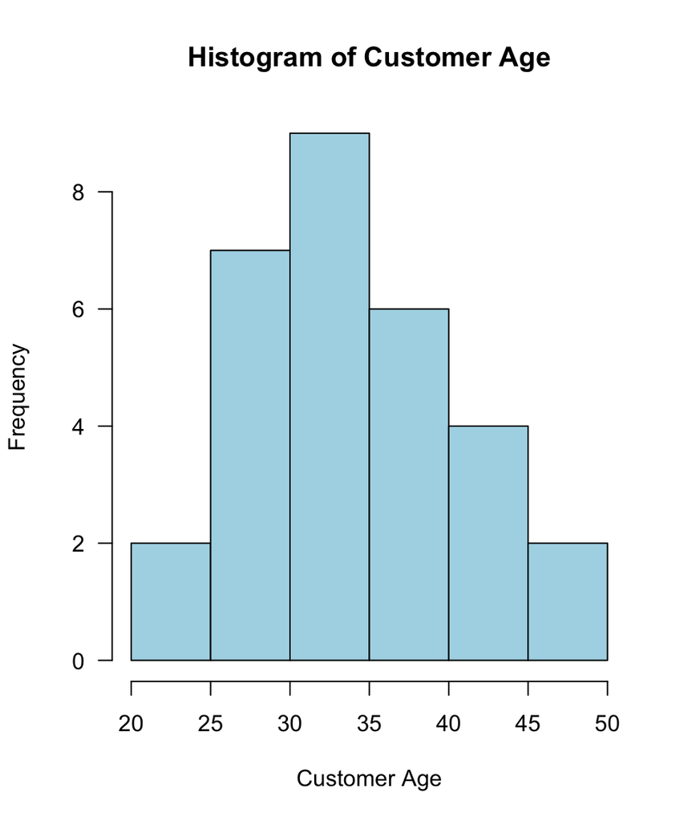

```r
#12. Histogram of Customer Age
hist(sales$Customer.Age,
     main = "Histogram of Customer Age",
     xlab = "Customer Age",
     col = "lightblue",
     border = "black",
     las = 1)
```

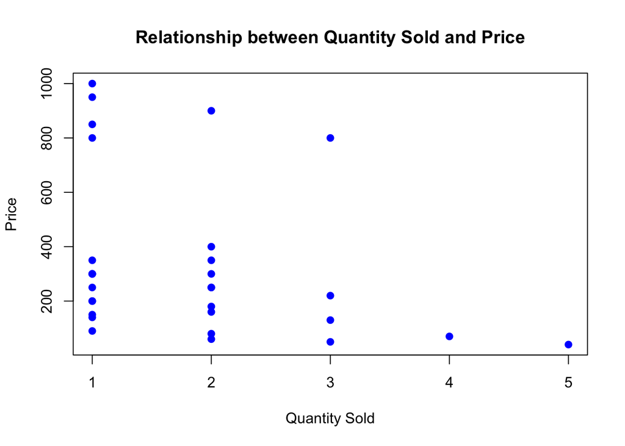

Figure 1: Scatter plot of the relationship between Quantity Sold and Price

```r
#13. Scatter plot of Quantity Sold and Price
plot(sales$Quantity.Sold, sales$Price,
     xlab = "Quantity Sold",
     ylab = "Price",
     main = "Relationship between Quantity Sold and Price",
     pch = 19,
     col = "blue")
```

#14. Analysis of the relationship between quantity sold and price

Based on the scatter plot, we can observe the following characteristics between price and quantity sold.

- Trend: There is no clear linear trend between price and quantity sold. The plot shows a varied distribution of data points without a consistent upward or downward pattern. This suggests changes in prices to not consistently affect quantity sold.
- Clusters: The data points are distributed across a range of prices and quantities sold. Products with lower prices have a higher range of quantities sold, while high-priced items show lower quantities sold.
- Outliters: There are several outliers where high priced items are sold in relatively small quantities. These outliers may represent conditions affecting sales.

In summary, the scatter plot Figure 1 shows that while there is some variability, there is no strong correlation of a relationship between quantity sold and price.